# INN_Learner_Notebook_Full_code (3)

1. This is a well-behaved model with strong generalization.
2. Training with SMOTE-balanced data and simplified architecture likely contributed to this stable learning pattern.
3. You may still benefit from early stopping if you want to optimize runtime — model likely converged by ~epoch 40.

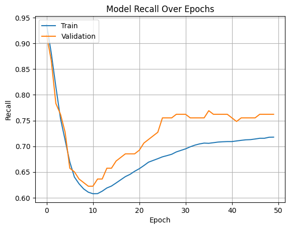

```python
plt.plot(history_3.history['recall'])
plt.plot(history_3.history['val_recall'])
plt.title('Model Recall Over Epochs')
plt.ylabel('Recall')  # ✅ Fix here
plt.xlabel('Epoch')
plt.legend(['Train', 'Validation'], loc='upper left')
plt.grid(True)
plt.show()
```

Observation :-

1. Both training and validation recall drop significantly in the early epochs.
2. Recall is high and stable on the validation set (~76%), meaning the model is highly capable of identifying churners.
3. Model generalizes better than it overfits, a sign of well-regularized learning.
4. SMOTE worked effectively, and the model benefits from it.

```python
y_train_pred = model_3.predict(X_train_smote)
#Predicting the results using 0.5 as the threshold
y_train_pred = (y_train_pred > 0.5)
y_train_pred
```

```
314/314 ━━━━━━━━━━━━━━━━━━━━ 2s 4ms/step
```

```
array([[False],
       [ True],
       [False],
       ...,
       [ True],
       [ True],
       [ True]])
```

```python
y_val_pred = model_3.predict(X_val)
#Predicting the results using 0.5 as the threshold
y_val_pred = (y_val_pred > 0.5)
y_val_pred
```

```
22/22 ━━━━━━━━━━━━━━━━━━━━ 0s 17ms/step
```

```
array([[False],
       [ True],
       [False],
       [False],
       [ True],
       [False],
       [ True],
       [False],
       [False],
       [ True],
       [False],
       [ True],
       [False],
       [False],
       [False],
       [ True],
       [ True],
       [ True],
       [False],
       [ True],
       [False],
       [False],
       [False],
       [False],
       [False],
       [False],
       [False],
       [ True],
       [False],
       [ True],
       [False],
       [ True],
       [False],
       [False],
       [False],
       [ True],
       [False],
       [False],
       [False],
       [False],
```

[output cut: 645 more lines]

```
       [False],
       [False],
       [ True],
       [ True],
       [False],
       [False],
       [False],
       [False],
       [False],
       [False],
       [ True],
       [False],
       [ True],
       [False],
       [False]])
```

```python
model_name = "NN with SMOTE & SGD"

train_metric_df.loc[model_name] = recall_score(y_train_smote,y_train_pred)
valid_metric_df.loc[model_name] = recall_score(y_val,y_val_pred)
```

```python
cr=classification_report(y_train_smote,y_train_pred)
print(cr)
```

```
              precision    recall  f1-score   support

         0.0       0.72      0.71      0.71      5017
         1.0       0.71      0.72      0.71      5017

    accuracy                           0.71     10034
   macro avg       0.71      0.71      0.71     10034
weighted avg       0.71      0.71      0.71     10034
```

```python
cr = classification_report(y_val, y_val_pred)
print(cr)
```

```
              precision    recall  f1-score   support

         0.0       0.92      0.68      0.78       557
         1.0       0.38      0.76      0.50       143

    accuracy                           0.69       700
   macro avg       0.65      0.72      0.64       700
weighted avg       0.81      0.69      0.72       700
```

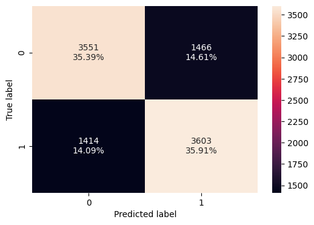

```python
make_confusion_matrix(y_train_smote, y_train_pred)
```

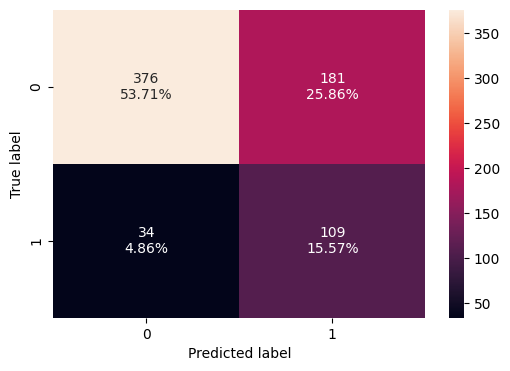

```python
make_confusion_matrix(y_val, y_val_pred)
```

### Neural Network with Balanced Data (by applying SMOTE) and Adam Optimizer

```python
backend.clear_session()
np.random.seed(2)
random.seed(2)
tf.random.set_seed(2)
```

```python
# Initializing the model
model_4 = Sequential()

# Input layer: 64 neurons, ReLU activation
model_4.add(Dense(64, activation='relu', input_dim=X_train_smote.shape[1]))

# Hidden layer 1: 32 neurons, ReLU activation
model_4.add(Dense(32, activation='relu'))

# Hidden layer 2: 16 neurons, ReLU activation
model_4.add(Dense(16, activation='relu'))

# Output layer: 1 neuron, sigmoid activation
model_4.add(Dense(1, activation='sigmoid'))
```

```python
model_4.summary()
```

```
Model: "sequential"
```

```
┏━━━━━━━━━━━━━━━━━━━━━━━━━━━━━━━━━┳━━━━━━━━━━━━━━━━━━━━━━━━┳━━━━━━━━━━━━━━━┓
┃ Layer (type)                    ┃ Output Shape           ┃       Param # ┃
┡━━━━━━━━━━━━━━━━━━━━━━━━━━━━━━━━━╇━━━━━━━━━━━━━━━━━━━━━━━━╇━━━━━━━━━━━━━━━┩
│ dense (Dense)                   │ (None, 64)             │           768 │
├─────────────────────────────────┼────────────────────────┼───────────────┤
│ dense_1 (Dense)                 │ (None, 32)             │         2,080 │
├─────────────────────────────────┼────────────────────────┼───────────────┤
│ dense_2 (Dense)                 │ (None, 16)             │           528 │
├─────────────────────────────────┼────────────────────────┼───────────────┤
│ dense_3 (Dense)                 │ (None, 1)              │            17 │
└─────────────────────────────────┴────────────────────────┴───────────────┘
```

```
 Total params: 3,393 (13.25 KB)
```

```
 Trainable params: 3,393 (13.25 KB)
```

```
 Non-trainable params: 0 (0.00 B)
```

```python
optimizer = tf.keras.optimizers.Adam()

# uncomment one of the following lines to define the metric to be used
# metric = 'accuracy'
# metric = keras.metrics.Recall()
# metric = keras.metrics.Precision()
# metric = keras.metrics.F1Score()
```

```python
metric = tf.keras.metrics.Recall()

# Compile the model
model_4.compile(loss='binary_crossentropy', optimizer=optimizer, metrics=[metric])
```

```python
model_4.summary()
```

```
Model: "sequential"
```

```
┏━━━━━━━━━━━━━━━━━━━━━━━━━━━━━━━━━┳━━━━━━━━━━━━━━━━━━━━━━━━┳━━━━━━━━━━━━━━━┓
┃ Layer (type)                    ┃ Output Shape           ┃       Param # ┃
┡━━━━━━━━━━━━━━━━━━━━━━━━━━━━━━━━━╇━━━━━━━━━━━━━━━━━━━━━━━━╇━━━━━━━━━━━━━━━┩
│ dense (Dense)                   │ (None, 64)             │           768 │
├─────────────────────────────────┼────────────────────────┼───────────────┤
│ dense_1 (Dense)                 │ (None, 32)             │         2,080 │
├─────────────────────────────────┼────────────────────────┼───────────────┤
│ dense_2 (Dense)                 │ (None, 16)             │           528 │
├─────────────────────────────────┼────────────────────────┼───────────────┤
│ dense_3 (Dense)                 │ (None, 1)              │            17 │
└─────────────────────────────────┴────────────────────────┴───────────────┘
```

```
 Total params: 3,393 (13.25 KB)
```

```
 Trainable params: 3,393 (13.25 KB)
```

```
 Non-trainable params: 0 (0.00 B)
```

```python
# Fitting the ANN
history_4 = model_4.fit(
    X_train_smote, y_train_smote,
    batch_size=32,       # Common default batch size
    epochs=50,           # Sufficient to observe learning and convergence
    verbose=1,
    validation_data=(X_val, y_val)
)
```

```
314/314 ━━━━━━━━━━━━━━━━━━━━ 5s 8ms/step - loss: 0.6153 - recall: 0.6995 - val_loss: 0.6098 - val_recall: 0.8252
314/314 ━━━━━━━━━━━━━━━━━━━━ 3s 4ms/step - loss: 0.5209 - recall: 0.7561 - val_loss: 0.5896 - val_recall: 0.8462
314/314 ━━━━━━━━━━━━━━━━━━━━ 1s 3ms/step - loss: 0.4784 - recall: 0.7860 - val_loss: 0.5775 - val_recall: 0.8462
314/314 ━━━━━━━━━━━━━━━━━━━━ 1s 3ms/step - loss: 0.4538 - recall: 0.7994 - val_loss: 0.5636 - val_recall: 0.8182
314/314 ━━━━━━━━━━━━━━━━━━━━ 1s 3ms/step - loss: 0.4362 - recall: 0.8041 - val_loss: 0.5506 - val_recall: 0.8112
314/314 ━━━━━━━━━━━━━━━━━━━━ 1s 3ms/step - loss: 0.4219 - recall: 0.8148 - val_loss: 0.5441 - val_recall: 0.8042
314/314 ━━━━━━━━━━━━━━━━━━━━ 1s 3ms/step - loss: 0.4111 - recall: 0.8230 - val_loss: 0.5377 - val_recall: 0.7972
314/314 ━━━━━━━━━━━━━━━━━━━━ 1s 3ms/step - loss: 0.4014 - recall: 0.8304 - val_loss: 0.5308 - val_recall: 0.7972
314/314 ━━━━━━━━━━━━━━━━━━━━ 1s 3ms/step - loss: 0.3931 - recall: 0.8345 - val_loss: 0.5293 - val_recall: 0.7832
314/314 ━━━━━━━━━━━━━━━━━━━━ 1s 3ms/step - loss: 0.3860 - recall: 0.8387 - val_loss: 0.5255 - val_recall: 0.7902
314/314 ━━━━━━━━━━━━━━━━━━━━ 1s 3ms/step - loss: 0.3787 - recall: 0.8431 - val_loss: 0.5235 - val_recall: 0.7832
314/314 ━━━━━━━━━━━━━━━━━━━━ 1s 3ms/step - loss: 0.3718 - recall: 0.8456 - val_loss: 0.5254 - val_recall: 0.7832
314/314 ━━━━━━━━━━━━━━━━━━━━ 1s 2ms/step - loss: 0.3649 - recall: 0.8516 - val_loss: 0.5238 - val_recall: 0.7832
314/314 ━━━━━━━━━━━━━━━━━━━━ 1s 4ms/step - loss: 0.3585 - recall: 0.8557 - val_loss: 0.5248 - val_recall: 0.7622
314/314 ━━━━━━━━━━━━━━━━━━━━ 1s 4ms/step - loss: 0.3530 - recall: 0.8597 - val_loss: 0.5199 - val_recall: 0.7552
314/314 ━━━━━━━━━━━━━━━━━━━━ 1s 4ms/step - loss: 0.3469 - recall: 0.8599 - val_loss: 0.5184 - val_recall: 0.7413
314/314 ━━━━━━━━━━━━━━━━━━━━ 1s 4ms/step - loss: 0.3422 - recall: 0.8653 - val_loss: 0.5179 - val_recall: 0.7413
314/314 ━━━━━━━━━━━━━━━━━━━━ 1s 4ms/step - loss: 0.3373 - recall: 0.8690 - val_loss: 0.5144 - val_recall: 0.7343
314/314 ━━━━━━━━━━━━━━━━━━━━ 2s 4ms/step - loss: 0.3330 - recall: 0.8696 - val_loss: 0.5151 - val_recall: 0.7413
314/314 ━━━━━━━━━━━━━━━━━━━━ 1s 3ms/step - loss: 0.3284 - recall: 0.8692 - val_loss: 0.5171 - val_recall: 0.7343
314/314 ━━━━━━━━━━━━━━━━━━━━ 1s 2ms/step - loss: 0.3240 - recall: 0.8710 - val_loss: 0.5206 - val_recall: 0.7273
314/314 ━━━━━━━━━━━━━━━━━━━━ 1s 3ms/step - loss: 0.3203 - recall: 0.8731 - val_loss: 0.5190 - val_recall: 0.7203
314/314 ━━━━━━━━━━━━━━━━━━━━ 1s 3ms/step - loss: 0.3160 - recall: 0.8794 - val_loss: 0.5228 - val_recall: 0.7133
314/314 ━━━━━━━━━━━━━━━━━━━━ 1s 4ms/step - loss: 0.3117 - recall: 0.8792 - val_loss: 0.5263 - val_recall: 0.7273
314/314 ━━━━━━━━━━━━━━━━━━━━ 1s 4ms/step - loss: 0.3075 - recall: 0.8847 - val_loss: 0.5261 - val_recall: 0.7203
314/314 ━━━━━━━━━━━━━━━━━━━━ 1s 3ms/step - loss: 0.3040 - recall: 0.8869 - val_loss: 0.5278 - val_recall: 0.7133
314/314 ━━━━━━━━━━━━━━━━━━━━ 1s 2ms/step - loss: 0.3008 - recall: 0.8895 - val_loss: 0.5371 - val_recall: 0.7203
314/314 ━━━━━━━━━━━━━━━━━━━━ 1s 3ms/step - loss: 0.2975 - recall: 0.8908 - val_loss: 0.5353 - val_recall: 0.7133
314/314 ━━━━━━━━━━━━━━━━━━━━ 1s 3ms/step - loss: 0.2939 - recall: 0.8932 - val_loss: 0.5394 - val_recall: 0.7063
314/314 ━━━━━━━━━━━━━━━━━━━━ 1s 3ms/step - loss: 0.2903 - recall: 0.8953 - val_loss: 0.5402 - val_recall: 0.6993
314/314 ━━━━━━━━━━━━━━━━━━━━ 1s 2ms/step - loss: 0.2869 - recall: 0.8995 - val_loss: 0.5401 - val_recall: 0.6923
314/314 ━━━━━━━━━━━━━━━━━━━━ 1s 3ms/step - loss: 0.2833 - recall: 0.8960 - val_loss: 0.5390 - val_recall: 0.6853
314/314 ━━━━━━━━━━━━━━━━━━━━ 1s 2ms/step - loss: 0.2797 - recall: 0.8993 - val_loss: 0.5363 - val_recall: 0.6853
314/314 ━━━━━━━━━━━━━━━━━━━━ 1s 3ms/step - loss: 0.2762 - recall: 0.9039 - val_loss: 0.5391 - val_recall: 0.6853
314/314 ━━━━━━━━━━━━━━━━━━━━ 2s 4ms/step - loss: 0.2731 - recall: 0.9035 - val_loss: 0.5395 - val_recall: 0.6923
314/314 ━━━━━━━━━━━━━━━━━━━━ 1s 4ms/step - loss: 0.2689 - recall: 0.9074 - val_loss: 0.5449 - val_recall: 0.6923
314/314 ━━━━━━━━━━━━━━━━━━━━ 1s 3ms/step - loss: 0.2658 - recall: 0.9085 - val_loss: 0.5496 - val_recall: 0.6783
314/314 ━━━━━━━━━━━━━━━━━━━━ 1s 3ms/step - loss: 0.2629 - recall: 0.9077 - val_loss: 0.5505 - val_recall: 0.6783
314/314 ━━━━━━━━━━━━━━━━━━━━ 1s 3ms/step - loss: 0.2606 - recall: 0.9087 - val_loss: 0.5551 - val_recall: 0.6783
314/314 ━━━━━━━━━━━━━━━━━━━━ 1s 3ms/step - loss: 0.2578 - recall: 0.9100 - val_loss: 0.5558 - val_recall: 0.6643
314/314 ━━━━━━━━━━━━━━━━━━━━ 1s 2ms/step - loss: 0.2550 - recall: 0.9107 - val_loss: 0.5640 - val_recall: 0.6783
314/314 ━━━━━━━━━━━━━━━━━━━━ 2s 5ms/step - loss: 0.2525 - recall: 0.9113 - val_loss: 0.5657 - val_recall: 0.6643
314/314 ━━━━━━━━━━━━━━━━━━━━ 2s 6ms/step - loss: 0.2500 - recall: 0.9135 - val_loss: 0.5713 - val_recall: 0.6783
314/314 ━━━━━━━━━━━━━━━━━━━━ 2s 5ms/step - loss: 0.2484 - recall: 0.9154 - val_loss: 0.5790 - val_recall: 0.6643
314/314 ━━━━━━━━━━━━━━━━━━━━ 4s 10ms/step - loss: 0.2458 - recall: 0.9155 - val_loss: 0.5780 - val_recall: 0.6713
314/314 ━━━━━━━━━━━━━━━━━━━━ 3s 9ms/step - loss: 0.2437 - recall: 0.9169 - val_loss: 0.5821 - val_recall: 0.6713
314/314 ━━━━━━━━━━━━━━━━━━━━ 3s 7ms/step - loss: 0.2410 - recall: 0.9175 - val_loss: 0.5882 - val_recall: 0.6573
314/314 ━━━━━━━━━━━━━━━━━━━━ 2s 6ms/step - loss: 0.2389 - recall: 0.9187 - val_loss: 0.5830 - val_recall: 0.6643
314/314 ━━━━━━━━━━━━━━━━━━━━ 1s 5ms/step - loss: 0.2371 - recall: 0.9171 - val_loss: 0.5910 - val_recall: 0.6783
314/314 ━━━━━━━━━━━━━━━━━━━━ 2s 7ms/step - loss: 0.2348 - recall: 0.9186 - val_loss: 0.5926 - val_recall: 0.6783
```

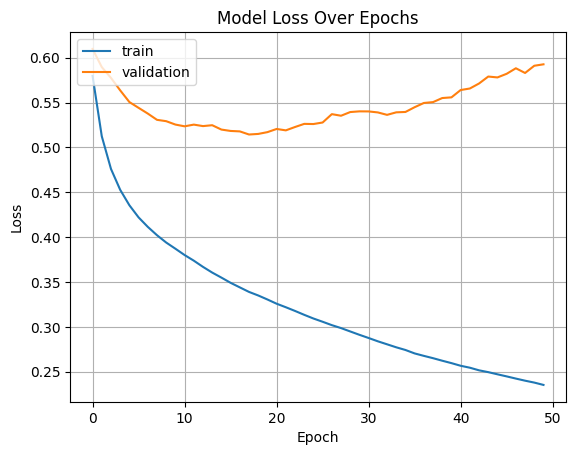

```python
plt.plot(history_4.history['loss'])        # Training loss per epoch
plt.plot(history_4.history['val_loss'])    # Validation loss per epoch
plt.title('Model Loss Over Epochs')
plt.ylabel('Loss')
plt.xlabel('Epoch')
plt.legend(['train', 'validation'], loc='upper left')
plt.grid(True)
plt.show()
```

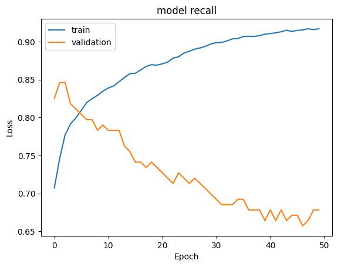

```python
#Plotting Train recall vs Validation recall
plt.plot(history_4.history['recall'])
plt.plot(history_4.history['val_recall'])
plt.title('model recall')
plt.ylabel('Loss')
plt.xlabel('Epoch')
plt.legend(['train', 'validation'], loc='upper left')
plt.show()
```

```python
y_train_pred = model_4.predict(X_train_smote)
y_train_pred = (y_train_pred > 0.5)
y_train_pred
```

```
314/314 ━━━━━━━━━━━━━━━━━━━━ 1s 2ms/step
```

```
array([[False],
       [False],
       [False],
       ...,
       [ True],
       [ True],
       [ True]])
```

```python
y_val_pred = model_4.predict(X_val)
y_val_pred = (y_val_pred > 0.5)
y_val_pred
```

```
22/22 ━━━━━━━━━━━━━━━━━━━━ 0s 7ms/step
```

```
array([[False],
       [False],
       [False],
       [ True],
       [False],
       [False],
       [False],
       [ True],
       [False],
       [ True],
       [False],
       [False],
       [False],
       [False],
       [ True],
       [False],
       [ True],
       [ True],
       [False],
       [False],
       [ True],
       [False],
       [False],
       [False],
       [False],
       [False],
       [False],
       [False],
       [False],
       [ True],
       [False],
       [False],
       [ True],
       [False],
       [False],
       [False],
       [False],
       [False],
       [False],
       [False],
```

[output cut: 645 more lines]

```
       [False],
       [False],
       [ True],
       [ True],
       [False],
       [False],
       [False],
       [False],
       [False],
       [False],
       [False],
       [False],
       [False],
       [ True],
       [False]])
```

```python
model_name = "NN with SMOTE & Adam"

train_metric_df.loc[model_name] = recall_score(y_train_smote,y_train_pred)
valid_metric_df.loc[model_name] = recall_score(y_val,y_val_pred)
```

```python
cr=classification_report(y_train_smote,y_train_pred)
print(cr)
```

```
              precision    recall  f1-score   support

         0.0       0.93      0.88      0.91      5017
         1.0       0.89      0.93      0.91      5017

    accuracy                           0.91     10034
   macro avg       0.91      0.91      0.91     10034
weighted avg       0.91      0.91      0.91     10034
```

```python
# Classification report
cr = classification_report(y_val, y_val_pred)
print(cr)
```

```
              precision    recall  f1-score   support

         0.0       0.91      0.81      0.86       557
         1.0       0.48      0.68      0.56       143

    accuracy                           0.78       700
   macro avg       0.69      0.74      0.71       700
weighted avg       0.82      0.78      0.80       700
```

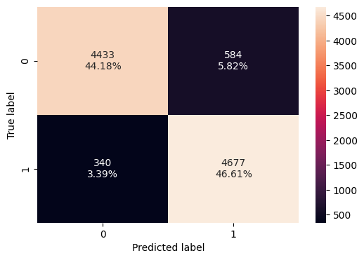

```python
make_confusion_matrix(y_train_smote, y_train_pred)
```

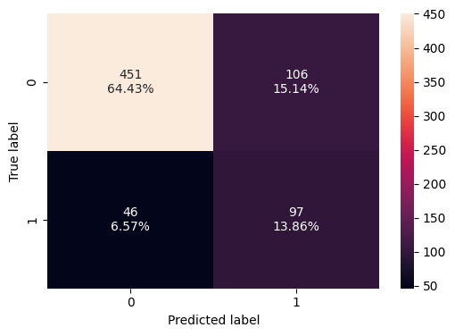

```python
make_confusion_matrix(y_val, y_val_pred)
```

### Neural Network with Balanced Data (by applying SMOTE), Adam Optimizer, and Dropout

```python
backend.clear_session()
np.random.seed(2)
random.seed(2)
tf.random.set_seed(2)
```

```python
# Initializing the model
model_5 = Sequential()
# Input layer: 64 neurons, ReLU activation
model_5.add(Dense(64, activation='relu', input_dim=X_train_smote.shape[1]))
# Dropout to reduce overfitting
model_5.add(Dropout(0.3))
# Hidden layer: 32 neurons, ReLU activation
model_5.add(Dense(32, activation='relu'))
# Dropout
model_5.add(Dropout(0.2))
# Hidden layer: 8 neurons, ReLU activation
model_5.add(Dense(8, activation='relu'))
# Output layer: 1 neuron, Sigmoid activation for binary classification
model_5.add(Dense(1, activation='sigmoid'))
```

```python
optimizer = tf.keras.optimizers.Adam()
```

```python
metric = tf.keras.metrics.Recall()

# Compile the model
model_5.compile(loss='binary_crossentropy', optimizer=optimizer, metrics=[metric])
```

```python
model_5.summary()
```

```
Model: "sequential"
```

```
┏━━━━━━━━━━━━━━━━━━━━━━━━━━━━━━━━━┳━━━━━━━━━━━━━━━━━━━━━━━━┳━━━━━━━━━━━━━━━┓
┃ Layer (type)                    ┃ Output Shape           ┃       Param # ┃
┡━━━━━━━━━━━━━━━━━━━━━━━━━━━━━━━━━╇━━━━━━━━━━━━━━━━━━━━━━━━╇━━━━━━━━━━━━━━━┩
│ dense (Dense)                   │ (None, 64)             │           768 │
├─────────────────────────────────┼────────────────────────┼───────────────┤
│ dropout (Dropout)               │ (None, 64)             │             0 │
├─────────────────────────────────┼────────────────────────┼───────────────┤
│ dense_1 (Dense)                 │ (None, 32)             │         2,080 │
├─────────────────────────────────┼────────────────────────┼───────────────┤
│ dropout_1 (Dropout)             │ (None, 32)             │             0 │
├─────────────────────────────────┼────────────────────────┼───────────────┤
│ dense_2 (Dense)                 │ (None, 8)              │           264 │
├─────────────────────────────────┼────────────────────────┼───────────────┤
│ dense_3 (Dense)                 │ (None, 1)              │             9 │
└─────────────────────────────────┴────────────────────────┴───────────────┘
```

```
 Total params: 3,121 (12.19 KB)
```

```
 Trainable params: 3,121 (12.19 KB)
```

```
 Non-trainable params: 0 (0.00 B)
```

```python
history_5 = model_5.fit(
    X_train_smote, y_train_smote,
    batch_size=32,
    epochs=50,
    verbose=1,
    validation_data=(X_val, y_val)
)
```

```
314/314 ━━━━━━━━━━━━━━━━━━━━ 10s 19ms/step - loss: 0.6577 - recall: 0.6326 - val_loss: 0.5860 - val_recall: 0.7692
314/314 ━━━━━━━━━━━━━━━━━━━━ 1s 4ms/step - loss: 0.5780 - recall: 0.7149 - val_loss: 0.5633 - val_recall: 0.7622
314/314 ━━━━━━━━━━━━━━━━━━━━ 2s 3ms/step - loss: 0.5617 - recall: 0.7114 - val_loss: 0.5602 - val_recall: 0.7343
314/314 ━━━━━━━━━━━━━━━━━━━━ 1s 3ms/step - loss: 0.5448 - recall: 0.7222 - val_loss: 0.5589 - val_recall: 0.7483
314/314 ━━━━━━━━━━━━━━━━━━━━ 1s 3ms/step - loss: 0.5361 - recall: 0.7180 - val_loss: 0.5412 - val_recall: 0.7483
314/314 ━━━━━━━━━━━━━━━━━━━━ 1s 3ms/step - loss: 0.5194 - recall: 0.7498 - val_loss: 0.5258 - val_recall: 0.7552
314/314 ━━━━━━━━━━━━━━━━━━━━ 2s 5ms/step - loss: 0.5056 - recall: 0.7482 - val_loss: 0.5211 - val_recall: 0.7762
314/314 ━━━━━━━━━━━━━━━━━━━━ 2s 5ms/step - loss: 0.4984 - recall: 0.7597 - val_loss: 0.5073 - val_recall: 0.8112
314/314 ━━━━━━━━━━━━━━━━━━━━ 2s 5ms/step - loss: 0.4817 - recall: 0.7671 - val_loss: 0.5043 - val_recall: 0.7832
314/314 ━━━━━━━━━━━━━━━━━━━━ 2s 5ms/step - loss: 0.4738 - recall: 0.7716 - val_loss: 0.4916 - val_recall: 0.8042
314/314 ━━━━━━━━━━━━━━━━━━━━ 2s 5ms/step - loss: 0.4637 - recall: 0.7783 - val_loss: 0.4878 - val_recall: 0.8252
314/314 ━━━━━━━━━━━━━━━━━━━━ 2s 5ms/step - loss: 0.4640 - recall: 0.7824 - val_loss: 0.4669 - val_recall: 0.8182
314/314 ━━━━━━━━━━━━━━━━━━━━ 2s 4ms/step - loss: 0.4536 - recall: 0.7880 - val_loss: 0.4850 - val_recall: 0.8112
314/314 ━━━━━━━━━━━━━━━━━━━━ 2s 4ms/step - loss: 0.4508 - recall: 0.7908 - val_loss: 0.4735 - val_recall: 0.8112
314/314 ━━━━━━━━━━━━━━━━━━━━ 1s 3ms/step - loss: 0.4372 - recall: 0.8045 - val_loss: 0.4720 - val_recall: 0.8042
314/314 ━━━━━━━━━━━━━━━━━━━━ 1s 3ms/step - loss: 0.4410 - recall: 0.7966 - val_loss: 0.4738 - val_recall: 0.7972
314/314 ━━━━━━━━━━━━━━━━━━━━ 1s 3ms/step - loss: 0.4392 - recall: 0.7981 - val_loss: 0.4640 - val_recall: 0.8182
314/314 ━━━━━━━━━━━━━━━━━━━━ 1s 3ms/step - loss: 0.4373 - recall: 0.7957 - val_loss: 0.4682 - val_recall: 0.7902
314/314 ━━━━━━━━━━━━━━━━━━━━ 1s 3ms/step - loss: 0.4292 - recall: 0.8035 - val_loss: 0.4625 - val_recall: 0.7902
314/314 ━━━━━━━━━━━━━━━━━━━━ 1s 3ms/step - loss: 0.4314 - recall: 0.8001 - val_loss: 0.4705 - val_recall: 0.8042
314/314 ━━━━━━━━━━━━━━━━━━━━ 1s 3ms/step - loss: 0.4243 - recall: 0.8134 - val_loss: 0.4678 - val_recall: 0.8112
314/314 ━━━━━━━━━━━━━━━━━━━━ 1s 3ms/step - loss: 0.4173 - recall: 0.8179 - val_loss: 0.4668 - val_recall: 0.7902
314/314 ━━━━━━━━━━━━━━━━━━━━ 1s 3ms/step - loss: 0.4235 - recall: 0.8106 - val_loss: 0.4667 - val_recall: 0.7832
314/314 ━━━━━━━━━━━━━━━━━━━━ 2s 4ms/step - loss: 0.4221 - recall: 0.8093 - val_loss: 0.4622 - val_recall: 0.7832
314/314 ━━━━━━━━━━━━━━━━━━━━ 1s 4ms/step - loss: 0.4205 - recall: 0.8122 - val_loss: 0.4579 - val_recall: 0.7762
314/314 ━━━━━━━━━━━━━━━━━━━━ 1s 3ms/step - loss: 0.4138 - recall: 0.8159 - val_loss: 0.4600 - val_recall: 0.7972
314/314 ━━━━━━━━━━━━━━━━━━━━ 1s 3ms/step - loss: 0.4149 - recall: 0.8181 - val_loss: 0.4477 - val_recall: 0.7832
314/314 ━━━━━━━━━━━━━━━━━━━━ 1s 3ms/step - loss: 0.4200 - recall: 0.8126 - val_loss: 0.4569 - val_recall: 0.7902
314/314 ━━━━━━━━━━━━━━━━━━━━ 1s 3ms/step - loss: 0.4119 - recall: 0.8203 - val_loss: 0.4605 - val_recall: 0.7832
314/314 ━━━━━━━━━━━━━━━━━━━━ 2s 4ms/step - loss: 0.4118 - recall: 0.8190 - val_loss: 0.4506 - val_recall: 0.7762
314/314 ━━━━━━━━━━━━━━━━━━━━ 1s 4ms/step - loss: 0.4084 - recall: 0.8199 - val_loss: 0.4552 - val_recall: 0.7762
314/314 ━━━━━━━━━━━━━━━━━━━━ 1s 3ms/step - loss: 0.4027 - recall: 0.8281 - val_loss: 0.4567 - val_recall: 0.7762
314/314 ━━━━━━━━━━━━━━━━━━━━ 1s 3ms/step - loss: 0.4068 - recall: 0.8219 - val_loss: 0.4499 - val_recall: 0.7692
314/314 ━━━━━━━━━━━━━━━━━━━━ 1s 3ms/step - loss: 0.4085 - recall: 0.8231 - val_loss: 0.4652 - val_recall: 0.7762
314/314 ━━━━━━━━━━━━━━━━━━━━ 2s 4ms/step - loss: 0.4151 - recall: 0.8111 - val_loss: 0.4626 - val_recall: 0.7902
314/314 ━━━━━━━━━━━━━━━━━━━━ 2s 3ms/step - loss: 0.3971 - recall: 0.8287 - val_loss: 0.4556 - val_recall: 0.7762
314/314 ━━━━━━━━━━━━━━━━━━━━ 1s 3ms/step - loss: 0.4035 - recall: 0.8316 - val_loss: 0.4515 - val_recall: 0.7762
314/314 ━━━━━━━━━━━━━━━━━━━━ 1s 3ms/step - loss: 0.3990 - recall: 0.8174 - val_loss: 0.4523 - val_recall: 0.7762
314/314 ━━━━━━━━━━━━━━━━━━━━ 1s 4ms/step - loss: 0.4048 - recall: 0.8280 - val_loss: 0.4618 - val_recall: 0.7692
314/314 ━━━━━━━━━━━━━━━━━━━━ 1s 4ms/step - loss: 0.3963 - recall: 0.8376 - val_loss: 0.4522 - val_recall: 0.7762
314/314 ━━━━━━━━━━━━━━━━━━━━ 1s 4ms/step - loss: 0.3936 - recall: 0.8299 - val_loss: 0.4639 - val_recall: 0.7832
314/314 ━━━━━━━━━━━━━━━━━━━━ 1s 4ms/step - loss: 0.4001 - recall: 0.8282 - val_loss: 0.4507 - val_recall: 0.7762
314/314 ━━━━━━━━━━━━━━━━━━━━ 1s 4ms/step - loss: 0.3926 - recall: 0.8338 - val_loss: 0.4562 - val_recall: 0.7902
314/314 ━━━━━━━━━━━━━━━━━━━━ 3s 5ms/step - loss: 0.3971 - recall: 0.8329 - val_loss: 0.4499 - val_recall: 0.7622
314/314 ━━━━━━━━━━━━━━━━━━━━ 1s 4ms/step - loss: 0.3988 - recall: 0.8271 - val_loss: 0.4461 - val_recall: 0.7762
314/314 ━━━━━━━━━━━━━━━━━━━━ 3s 4ms/step - loss: 0.3906 - recall: 0.8323 - val_loss: 0.4541 - val_recall: 0.7622
314/314 ━━━━━━━━━━━━━━━━━━━━ 2s 3ms/step - loss: 0.3899 - recall: 0.8333 - val_loss: 0.4557 - val_recall: 0.7692
314/314 ━━━━━━━━━━━━━━━━━━━━ 1s 3ms/step - loss: 0.3882 - recall: 0.8423 - val_loss: 0.4593 - val_recall: 0.7762
314/314 ━━━━━━━━━━━━━━━━━━━━ 1s 3ms/step - loss: 0.3899 - recall: 0.8320 - val_loss: 0.4572 - val_recall: 0.7832
314/314 ━━━━━━━━━━━━━━━━━━━━ 1s 3ms/step - loss: 0.3848 - recall: 0.8364 - val_loss: 0.4552 - val_recall: 0.7762
```

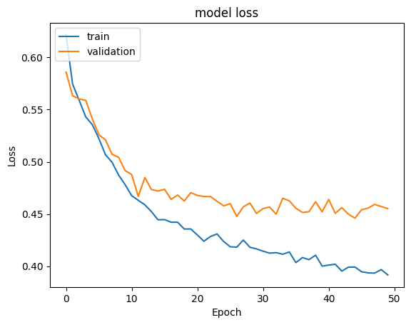

```python
#Plotting Train Loss vs Validation Loss
plt.plot(history_5.history['loss'])
plt.plot(history_5.history['val_loss'])
plt.title('model loss')
plt.ylabel('Loss')
plt.xlabel('Epoch')
plt.legend(['train', 'validation'], loc='upper left')
plt.show()
```

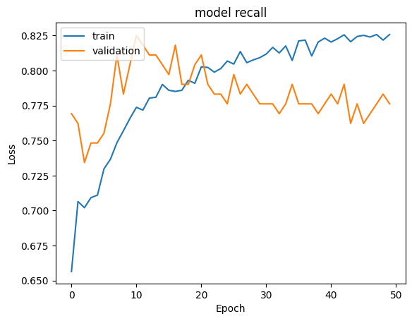

```python
#Plotting Train recall vs Validation recall
plt.plot(history_5.history['recall'])
plt.plot(history_5.history['val_recall'])
plt.title('model recall')
plt.ylabel('Loss')
plt.xlabel('Epoch')
plt.legend(['train', 'validation'], loc='upper left')
plt.show()
```

```python
y_train_pred = model_5.predict(X_train_smote)
y_train_pred = (y_train_pred > 0.5)
y_train_pred
```

```
314/314 ━━━━━━━━━━━━━━━━━━━━ 1s 2ms/step
```

```
array([[False],
       [False],
       [False],
       ...,
       [ True],
       [ True],
       [ True]])
```

```python
y_val_pred = model_5.predict(X_val)
y_val_pred = (y_val_pred > 0.5)
y_val_pred
```

```
22/22 ━━━━━━━━━━━━━━━━━━━━ 0s 7ms/step
```

```
array([[False],
       [False],
       [False],
       [False],
       [False],
       [False],
       [ True],
       [ True],
       [False],
       [ True],
       [False],
       [ True],
       [False],
       [False],
       [ True],
       [False],
       [ True],
       [ True],
       [False],
       [False],
       [ True],
       [False],
       [False],
       [False],
       [False],
       [False],
       [False],
       [ True],
       [False],
       [ True],
       [False],
       [False],
       [ True],
       [False],
       [False],
       [ True],
       [ True],
       [False],
       [False],
       [False],
```

[output cut: 645 more lines]

```
       [False],
       [False],
       [ True],
       [ True],
       [False],
       [False],
       [False],
       [False],
       [False],
       [False],
       [False],
       [False],
       [False],
       [False],
       [False]])
```

```python
model_name = "NN with SMOTE,Adam & Dropout"

train_metric_df.loc[model_name] = recall_score(y_train_smote,y_train_pred)
valid_metric_df.loc[model_name] = recall_score(y_val,y_val_pred)
```

```python
cr=classification_report(y_train_smote,y_train_pred)
print(cr)
```

```
              precision    recall  f1-score   support

         0.0       0.87      0.83      0.85      5017
         1.0       0.84      0.88      0.86      5017

    accuracy                           0.85     10034
   macro avg       0.85      0.85      0.85     10034
weighted avg       0.85      0.85      0.85     10034
```

```python
# Generate classification report
cr = classification_report(y_val, y_val_pred)
print(cr)
```

```
              precision    recall  f1-score   support

         0.0       0.93      0.79      0.85       557
         1.0       0.48      0.78      0.60       143

    accuracy                           0.79       700
   macro avg       0.71      0.78      0.73       700
weighted avg       0.84      0.79      0.80       700
```

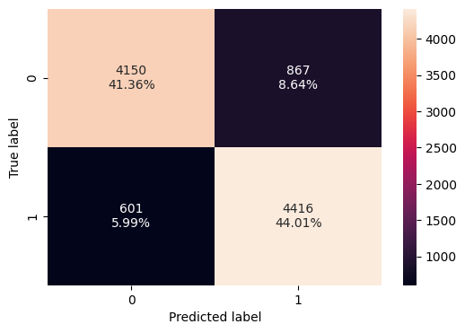

```python
#Calculating the confusion matrix
make_confusion_matrix(y_train_smote, y_train_pred)
```

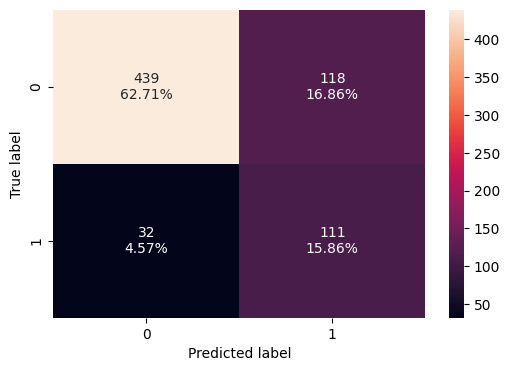

```python
make_confusion_matrix(y_val, y_val_pred)
```

## Model Performance Comparison and Final Model Selection

```python
print("Training performance comparison")
train_metric_df
```

```
Training performance comparison
```

|  | recall |
| --- | --- |
| NN with Adam & Dropout | 0.639127 |
| NN with Adam | 0.537802 |
| NN with SMOTE & SGD | 0.718158 |
| NN with SMOTE & Adam | 0.932230 |
| NN with SMOTE,Adam & Dropout | 0.880207 |

Observation :-

1. SMOTE is the most impactful for improving recall in churn prediction by balancing the class distribution.
2. Adam outperforms SGD when paired with SMOTE, offering better convergence and performance.
3. Dropout improves generalization but may slightly reduce recall when over-regularized.

```python
print("Validation set performance comparison")
valid_metric_df
```

```
Validation set performance comparison
```

|  | recall |
| --- | --- |
| NN with Adam & Dropout | 0.552448 |
| NN with Adam | 0.503497 |
| NN with SMOTE & SGD | 0.762238 |
| NN with SMOTE & Adam | 0.678322 |
| NN with SMOTE,Adam & Dropout | 0.776224 |

Observation :-

1. SMOTE is essential: All models using SMOTE significantly outperform those without it, proving it's critical for handling class imbalance in churn prediction.
2. Dropout helps fine-tune recall: When paired with SMOTE and Adam, dropout leads to the best generalization and highest recall (0.776).
3. Adam vs. SGD: Adam with Dropout is more effective than SGD in this case, likely due to better adaptive learning in the presence of synthetic data.

```python
train_metric_df - valid_metric_df
```

|  | recall |
| --- | --- |
| NN with Adam & Dropout | 0.086679 |
| NN with Adam | 0.034306 |
| NN with SMOTE & SGD | -0.044080 |
| NN with SMOTE & Adam | 0.253909 |
| NN with SMOTE,Adam & Dropout | 0.103984 |

Observation ::-

1. Best Generalization: "NN with SMOTE & SGD" — Validation recall is even slightly higher than training recall, indicating excellent generalization.
2. Worst Generalization : NN with SMOTE & Adam" — High training recall but a large drop on validation suggests overfitting; would benefit from adding dropout or using early stopping.

```python
# Use the best model to predict on the test set
y_test_pred = model_5.predict(X_test)

# Apply threshold to convert probabilities to binary predictions
y_test_pred = (y_test_pred > 0.5).astype(int)

# Display predictions
print(y_test_pred)
```

```
94/94 ━━━━━━━━━━━━━━━━━━━━ 1s 8ms/step
[[0]
 [0]
 [0]
 ...
 [1]
 [1]
 [0]]
```

```python
#lets print classification report
cr=classification_report(y_test,y_test_pred)
print(cr)
```

```
              precision    recall  f1-score   support

         0.0       0.93      0.81      0.86      2389
         1.0       0.50      0.75      0.60       611

    accuracy                           0.79      3000
   macro avg       0.71      0.78      0.73      3000
weighted avg       0.84      0.79      0.81      3000
```

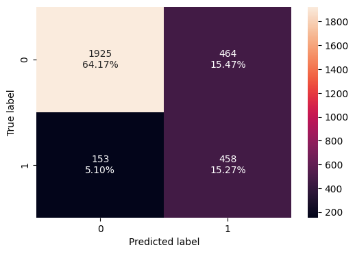

```python
#Calculating the confusion matrix
make_confusion_matrix(y_test,y_test_pred)
```

## Actionable Insights and Business Recommendations

Actionable Insights from Model Performance

1. Churn Can Be Predicted with High Accuracy Best model (NN with SMOTE, Adam & Dropout) achieved a validation recall of 77.6%.
2. Class Imbalance Was a Major Challenge
3. Regularization Improves Generalization Dropout helped reduce overfitting, leading to a well-generalized model on unseen data.

Business Recommendations

1. Target At-Risk Customers with Personalized Offers For customers identified as high risk: Offer custom retention incentives (discounts, upgrades, loyalty points). Route them to special customer support teams.
2. Focus Marketing Spend More Efficiently Prioritize marketing and communication toward the most likely to churn segment rather than broad campaigns. Helps reduce cost of retention and improve ROI.
3. Monitor Model Performance Periodically Set up model monitoring to track recall, precision, and drift. Retrain quarterly with updated data to maintain high performance.
4. Collect Feedback and Improve Features Encourage business units to collect feedback from churners to enhance feature engineering and explainability. Incorporate usage patterns, support call logs, or survey scores to enrich the model.

Power Ahead